# Lab4

Marlee_Galloway

9/14/2020

```r
library(tidyverse)
report_03_11_2020 <-   read_csv(url("https://raw.githubusercontent.com/CSSEGISandData/COVID-19/master/csse_covid_19_data/csse_covid_19_daily_reports/03-11-2020.csv")) %>%
  rename(Country_Region = "Country/Region", Province_State = "Province/State")
str(report_03_11_2020)
```

```
## tibble [216 × 8] (S3: spec_tbl_df/tbl_df/tbl/data.frame)
##  $ Province_State: chr [1:216] "Hubei" NA NA NA ...
##  $ Country_Region: chr [1:216] "China" "Italy" "Iran" "Korea, South" ...
##  $ Last Update   : POSIXct[1:216], format: "2020-03-11 10:53:02" "2020-03-11 21:33:02" ...
##  $ Confirmed     : num [1:216] 67773 12462 9000 7755 2281 ...
##  $ Deaths        : num [1:216] 3046 827 354 60 48 ...
##  $ Recovered     : num [1:216] 49134 1045 2959 288 12 ...
##  $ Latitude      : num [1:216] 31 43 32 36 46.2 ...
##  $ Longitude     : num [1:216] 112.27 12 53 128 2.21 ...
##  - attr(*, "spec")=
##   .. cols(
##   ..   `Province/State` = col_character(),
##   ..   `Country/Region` = col_character(),
##   ..   `Last Update` = col_datetime(format = ""),
##   ..   Confirmed = col_double(),
##   ..   Deaths = col_double(),
##   ..   Recovered = col_double(),
##   ..   Latitude = col_double(),
##   ..   Longitude = col_double()
##   .. )
```

#Interactive data tables with the DT Package

```r
library(DT)
datatable(report_03_11_2020)
```

|  | Province_State | Country_Region | Last Update | Confirmed | Deaths | Recovered | Latitude | Longitude |
| --- | --- | --- | --- | --- | --- | --- | --- | --- |
| 1 | Hubei | China | 2020-03-11T10:53:02Z | 67773 | 3046 | 49134 | 30.9756 | 112.2707 |
| 2 |  | Italy | 2020-03-11T21:33:02Z | 12462 | 827 | 1045 | 43 | 12 |
| 3 |  | Iran | 2020-03-11T18:52:03Z | 9000 | 354 | 2959 | 32 | 53 |
| 4 |  | Korea, South | 2020-03-11T21:13:18Z | 7755 | 60 | 288 | 36 | 128 |
| 5 | France | France | 2020-03-11T22:53:03Z | 2281 | 48 | 12 | 46.2276 | 2.2137 |
| 6 |  | Spain | 2020-03-11T20:53:02Z | 2277 | 54 | 183 | 40 | -4 |
| 7 |  | Germany | 2020-03-11T19:13:17Z | 1908 | 3 | 25 | 51 | 9 |
| 8 | Guangdong | China | 2020-03-11T10:13:06Z | 1356 | 8 | 1282 | 23.3417 | 113.4244 |
| 9 | Henan | China | 2020-03-11T08:13:09Z | 1273 | 22 | 1249 | 33.882 | 113.614 |
| 10 | Zhejiang | China | 2020-03-11T09:33:12Z | 1215 | 1 | 1195 | 29.1832 | 120.0934 |

[output cut: 206 more lines]

###Exercises Part 1

#1. The format of the daily reports has changed over time. What are the differences between 3/13/2020, the Friday before spring break 2020 and yesterday 6 months later on 9/13/2020? Load the files into R and use str() and View() (or in the top right corner click on Environment and then the data frame.). Note the in the more recent dates they have changed the column headers so that it is no longer necessary to rename Province_State and Country_Region.

```r
report_03_13_2020 <-   read_csv(url("https://raw.githubusercontent.com/CSSEGISandData/COVID-19/master/csse_covid_19_data/csse_covid_19_daily_reports/03-13-2020.csv")) %>%
  rename(Country_Region = "Country/Region", Province_State = "Province/State")
report_09_13_2020 <-   read_csv(url("https://raw.githubusercontent.com/CSSEGISandData/COVID-19/master/csse_covid_19_data/csse_covid_19_daily_reports/09-13-2020.csv"))
str(report_03_13_2020)
```

```
## tibble [230 × 8] (S3: spec_tbl_df/tbl_df/tbl/data.frame)
##  $ Province_State: chr [1:230] "Hubei" "Guangdong" "Henan" "Zhejiang" ...
##  $ Country_Region: chr [1:230] "China" "China" "China" "China" ...
##  $ Last Update   : POSIXct[1:230], format: "2020-03-13 11:09:03" "2020-03-13 11:09:03" ...
##  $ Confirmed     : num [1:230] 67786 1356 1273 1215 1018 ...
##  $ Deaths        : num [1:230] 3062 8 22 1 4 ...
##  $ Recovered     : num [1:230] 51553 1296 1249 1197 1005 ...
##  $ Latitude      : num [1:230] 31 23.3 33.9 29.2 27.6 ...
##  $ Longitude     : num [1:230] 112 113 114 120 112 ...
##  - attr(*, "spec")=
##   .. cols(
##   ..   `Province/State` = col_character(),
##   ..   `Country/Region` = col_character(),
##   ..   `Last Update` = col_datetime(format = ""),
##   ..   Confirmed = col_double(),
##   ..   Deaths = col_double(),
##   ..   Recovered = col_double(),
##   ..   Latitude = col_double(),
##   ..   Longitude = col_double()
##   .. )
```

```r
view(report_03_13_2020)
```

```r
str(report_09_13_2020)
```

```
## tibble [3,954 × 14] (S3: spec_tbl_df/tbl_df/tbl/data.frame)
##  $ FIPS               : num [1:3954] NA NA NA NA NA NA NA NA NA NA ...
##  $ Admin2             : chr [1:3954] NA NA NA NA ...
##  $ Province_State     : chr [1:3954] NA NA NA NA ...
##  $ Country_Region     : chr [1:3954] "Afghanistan" "Albania" "Algeria" "Andorra" ...
##  $ Last_Update        : POSIXct[1:3954], format: "2020-09-14 04:26:09" "2020-09-14 04:26:09" ...
##  $ Lat                : num [1:3954] 33.9 41.2 28 42.5 -11.2 ...
##  $ Long_              : num [1:3954] 67.71 20.17 1.66 1.52 17.87 ...
##  $ Confirmed          : num [1:3954] 38716 11353 48254 1344 3388 ...
##  $ Deaths             : num [1:3954] 1420 334 1612 53 134 ...
##  $ Recovered          : num [1:3954] 31638 6569 34037 943 1301 ...
##  $ Active             : num [1:3954] 5658 4450 12605 348 1953 ...
##  $ Combined_Key       : chr [1:3954] "Afghanistan" "Albania" "Algeria" "Andorra" ...
##  $ Incidence_Rate     : num [1:3954] 99.5 394.5 110 1739.5 10.3 ...
##  $ Case-Fatality_Ratio: num [1:3954] 3.67 2.94 3.34 3.94 3.96 ...
##  - attr(*, "spec")=
##   .. cols(
##   ..   FIPS = col_double(),
##   ..   Admin2 = col_character(),
##   ..   Province_State = col_character(),
##   ..   Country_Region = col_character(),
##   ..   Last_Update = col_datetime(format = ""),
##   ..   Lat = col_double(),
##   ..   Long_ = col_double(),
##   ..   Confirmed = col_double(),
##   ..   Deaths = col_double(),
##   ..   Recovered = col_double(),
##   ..   Active = col_double(),
##   ..   Combined_Key = col_character(),
##   ..   Incidence_Rate = col_double(),
##   ..   `Case-Fatality_Ratio` = col_double()
##   .. )
```

```r
view(report_09_13_2020)
```

#2. Many countries have multiple entries representing different regions (e.g. counties and states). To get the counts for a country we need to summarise the data. Use group_by() and summarize() to make a data frame (tibble) with total counts for each country.

```r
report_09_13_2020 %>%
  group_by(Country_Region) %>%
  summarize(Deaths = sum(Deaths, na.rm = TRUE))
```

```
## # A tibble: 188 x 2
##    Country_Region      Deaths
##    <chr>                <dbl>
##  1 Afghanistan           1420
##  2 Albania                334
##  3 Algeria               1612
##  4 Andorra                 53
##  5 Angola                 134
##  6 Antigua and Barbuda      3
##  7 Argentina            11352
##  8 Armenia                916
##  9 Australia              816
## 10 Austria                756
## # … with 178 more rows
```

#3. To get counts for confirmed cases per U.S state use filter() to select US and group_by and summarize as above.

```r
filter(report_09_13_2020, Country_Region == "US") %>%
  group_by(Province_State) %>%
  summarize(Confirmed = sum(Confirmed, na.rm = TRUE))
```

```
## # A tibble: 58 x 2
##    Province_State       Confirmed
##    <chr>                    <dbl>
##  1 Alabama                 138755
##  2 Alaska                    6268
##  3 Arizona                 208512
##  4 Arkansas                 70219
##  5 California              761728
##  6 Colorado                 61293
##  7 Connecticut              54326
##  8 Delaware                 18849
##  9 Diamond Princess            49
## 10 District of Columbia     14592
## # … with 48 more rows
```

#4. It will be difficult to make simple graphs with the data from all countries in the world or even the US states. Use arrange_by() and slice() to get just the top 10 countries for Deaths.

```r
  top_10_countries_deaths <- arrange(report_09_13_2020, Country_Region) %>%
  slice_max(Deaths, n=10)
```

###Exercises Part 2

#Make plots using geom_point() of the 10 countries with the confirmed cases and deaths (two separate graphs) on 3/12/2020 and 9/12/2020.

#03/12/2020:

```r
report_03_12_2020 <-   read_csv(url("https://raw.githubusercontent.com/CSSEGISandData/COVID-19/master/csse_covid_19_data/csse_covid_19_daily_reports/03-12-2020.csv")) %>%
  rename(Country_Region = "Country/Region", Province_State = "Province/State")
top_10_countries_confirmed <- arrange(report_03_12_2020, Country_Region) %>%
  slice_max(Confirmed, n=10)
```

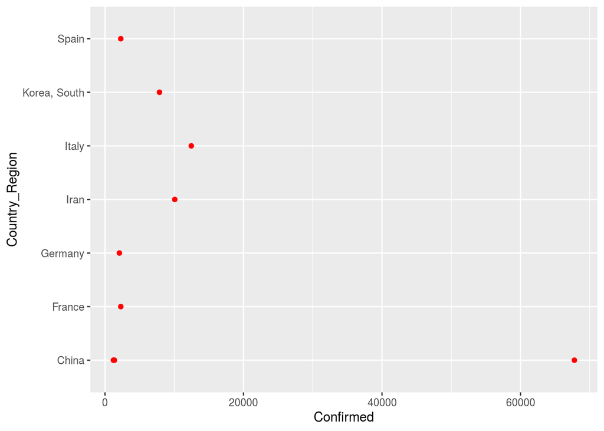

```r
ggplot(data = top_10_countries_confirmed, aes(x = Confirmed, y = Country_Region)) +
  geom_point(alpha = 1, color = "red")
```

```r
top_10_countries_deaths <- arrange(report_03_12_2020, Country_Region) %>%
  slice_max(Deaths, n=10)
```

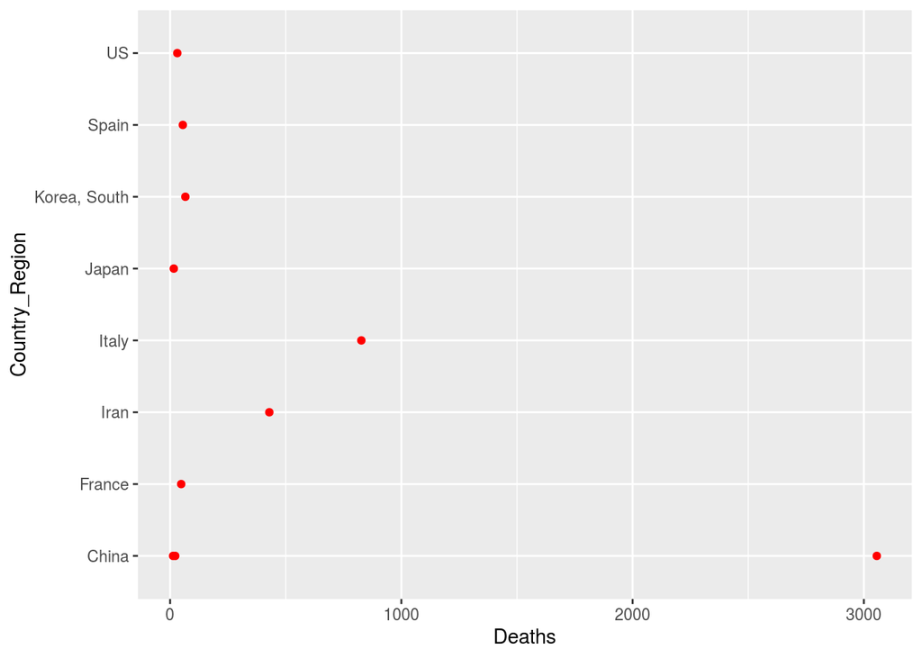

```r
ggplot(data = top_10_countries_deaths, aes(x = Deaths, y = Country_Region)) +
  geom_point(alpha = 1, color = "red")
```

#9/12/2020:

```r
report_09_12_2020 <-   read_csv(url("https://raw.githubusercontent.com/CSSEGISandData/COVID-19/master/csse_covid_19_data/csse_covid_19_daily_reports/09-12-2020.csv"))
top_10_countries_confirmed <- arrange(report_09_12_2020, Country_Region) %>%
  slice_max(Confirmed, n=10)
```

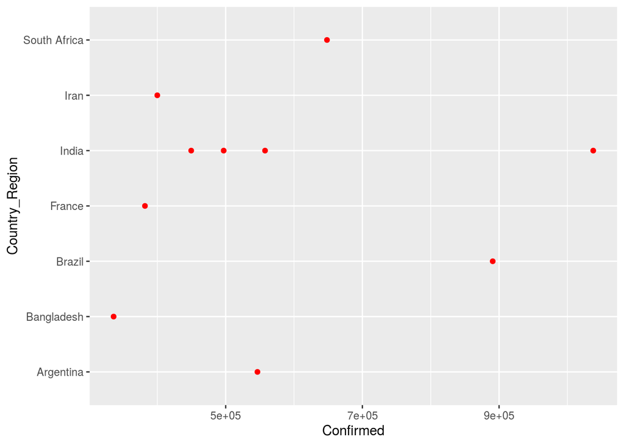

```r
ggplot(data = top_10_countries_confirmed, aes(x = Confirmed, y = Country_Region)) +
  geom_point(alpha = 1, color = "red")
```

```r
top_10_countries_deaths <- arrange(report_09_12_2020, Country_Region) %>%
  slice_max(Deaths, n=10)
```

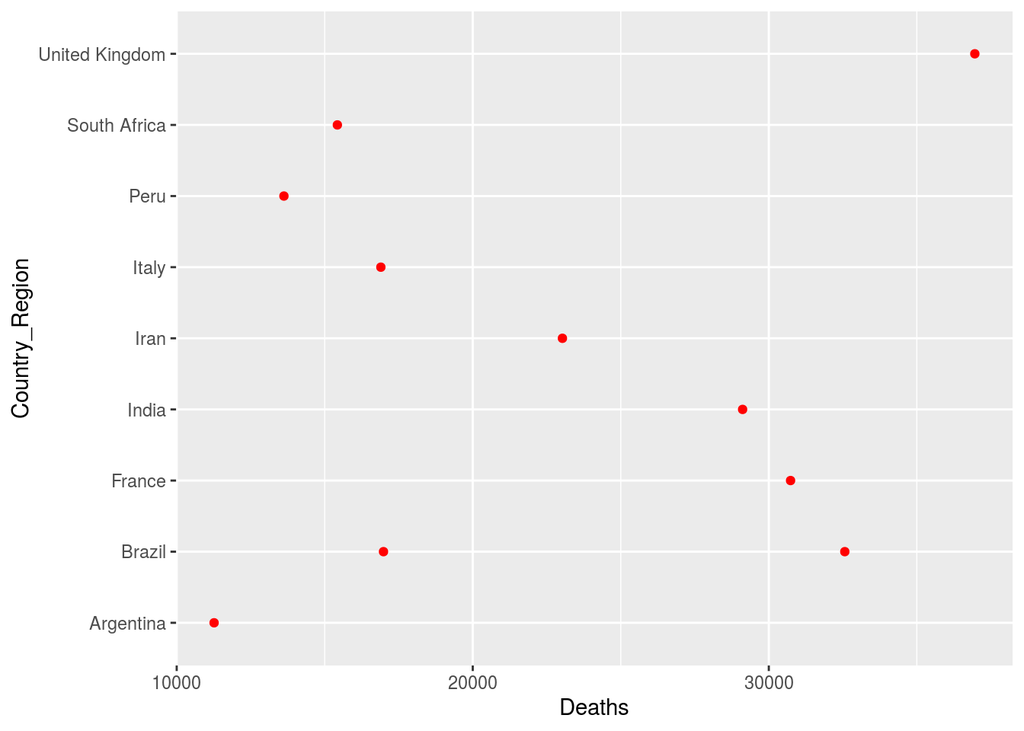

```r
ggplot(data = top_10_countries_deaths, aes(x = Deaths, y = Country_Region)) +
  geom_point(alpha = 1, color = "red")
```

#Make using geom_bar of the 10 states with the most confirmed cases and deaths (two separate graphs) on 3/12/2020 and 9/12/2020.

#3/12/2020:

```r
top_10_states_confirmed <- report_03_12_2020 %>%
    filter(Country_Region =="US") %>%
    group_by(Province_State) %>%
    summarize(confirmed_cases = sum(Confirmed)) %>%
    arrange(desc(confirmed_cases)) %>%
    slice(1:10)
```

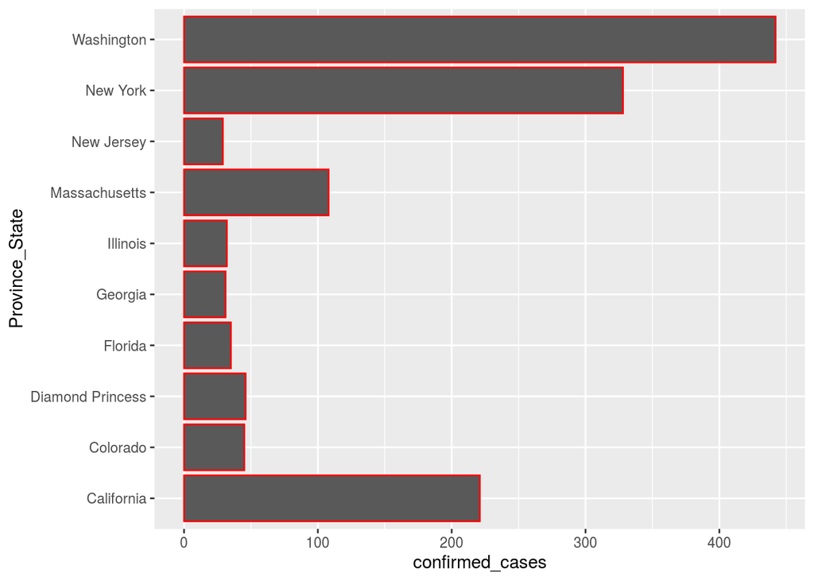

```r
ggplot(data = top_10_states_confirmed, aes(x = confirmed_cases, y = Province_State)) +
geom_bar(stat = 'identity', color = "red")
```

```r
top_10_states_deaths <- report_03_12_2020 %>%
  filter(Country_Region == "US") %>%
  group_by(Province_State) %>%
  summarize(total_deaths = sum(Deaths)) %>%
  arrange(desc(total_deaths)) %>%
  slice(1:10)
```

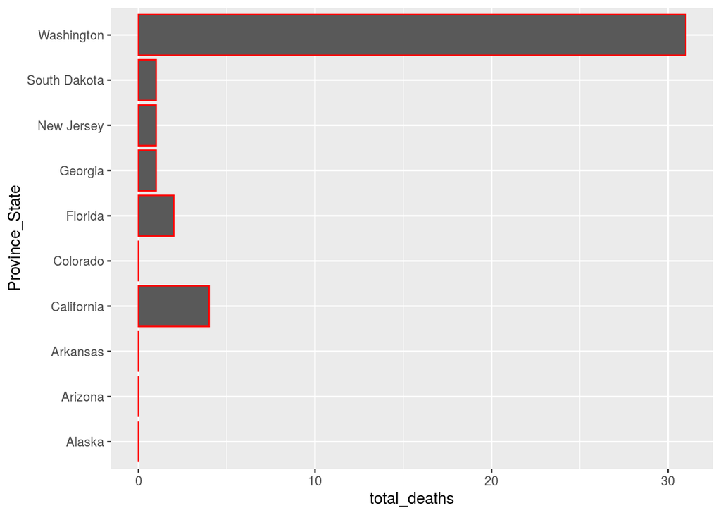

```r
ggplot(data = top_10_states_deaths, aes(x = total_deaths, y = Province_State)) +
  geom_bar(stat = 'identity', color = "red")
```

#9/12/2020:

```r
top_10_states_confirmed2 <- report_09_12_2020 %>%
    filter(Country_Region =="US") %>%
    group_by(Province_State) %>%
    summarize(confirmed_cases = sum(Confirmed)) %>%
    arrange(desc(confirmed_cases)) %>%
    slice(1:10)
```

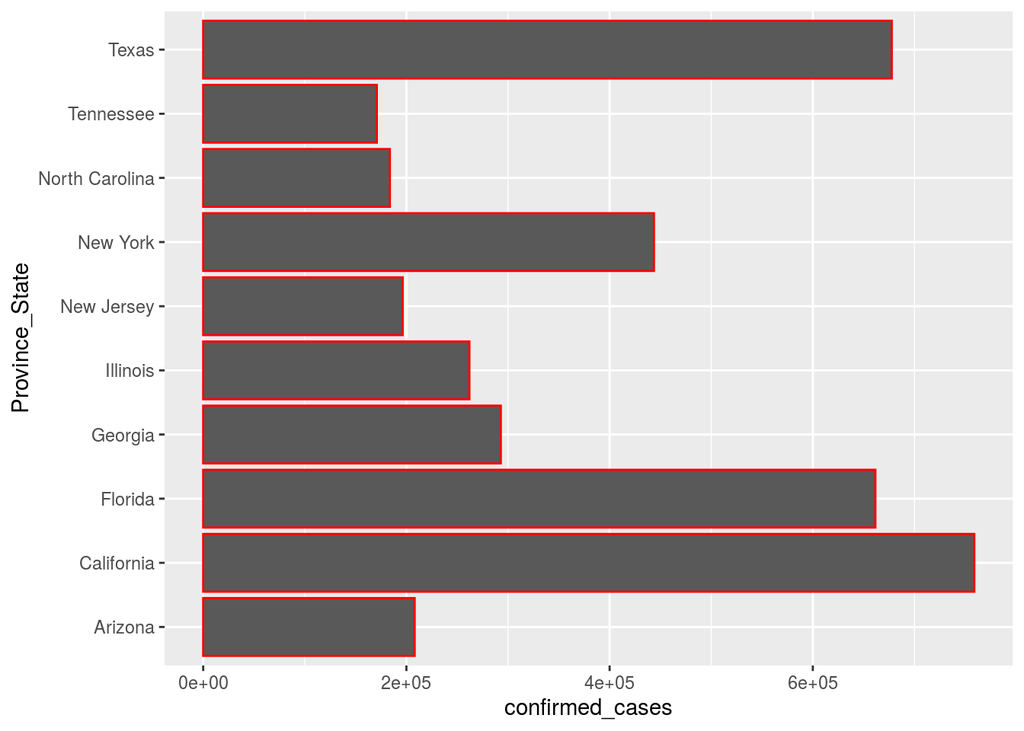

```r
ggplot(data = top_10_states_confirmed2, aes(x = confirmed_cases, y = Province_State)) +
geom_bar(stat = 'identity', color = "red")
```

```r
top_10_states_deaths2 <- report_09_12_2020 %>%
  filter(Country_Region == "US") %>%
  group_by(Province_State) %>%
  summarize(total_deaths = sum(Deaths)) %>%
  arrange(desc(total_deaths)) %>%
  slice(1:10)
```

[figure not shown]

```r
ggplot(data = top_10_states_deaths, aes(x = total_deaths, y = Province_State)) +
  geom_bar(stat = 'identity', color = "red")
```